# Analysis of White Wines by Rikpratim Mazumdar

This dataset is about the White Wines and the various factors that affect the quality of wines. It contains variables such as residual sugar, alcohol content, citric acid content, pH levels, etc.

# Univariate Plots Section

Let’s have a look at the summary of all the variables.

```
##        X        fixed.acidity    volatile.acidity  citric.acid
##  Min.   :   1   Min.   : 3.800   Min.   :0.0800   Min.   :0.0000
##  1st Qu.:1225   1st Qu.: 6.300   1st Qu.:0.2100   1st Qu.:0.2700
##  Median :2450   Median : 6.800   Median :0.2600   Median :0.3200
##  Mean   :2450   Mean   : 6.855   Mean   :0.2782   Mean   :0.3342
##  3rd Qu.:3674   3rd Qu.: 7.300   3rd Qu.:0.3200   3rd Qu.:0.3900
##  Max.   :4898   Max.   :14.200   Max.   :1.1000   Max.   :1.6600
##  residual.sugar     chlorides       free.sulfur.dioxide
##  Min.   : 0.600   Min.   :0.00900   Min.   :  2.00
##  1st Qu.: 1.700   1st Qu.:0.03600   1st Qu.: 23.00
##  Median : 5.200   Median :0.04300   Median : 34.00
##  Mean   : 6.391   Mean   :0.04577   Mean   : 35.31
##  3rd Qu.: 9.900   3rd Qu.:0.05000   3rd Qu.: 46.00
##  Max.   :65.800   Max.   :0.34600   Max.   :289.00
##  total.sulfur.dioxide    density             pH          sulphates
##  Min.   :  9.0        Min.   :0.9871   Min.   :2.720   Min.   :0.2200
##  1st Qu.:108.0        1st Qu.:0.9917   1st Qu.:3.090   1st Qu.:0.4100
##  Median :134.0        Median :0.9937   Median :3.180   Median :0.4700
##  Mean   :138.4        Mean   :0.9940   Mean   :3.188   Mean   :0.4898
##  3rd Qu.:167.0        3rd Qu.:0.9961   3rd Qu.:3.280   3rd Qu.:0.5500
##  Max.   :440.0        Max.   :1.0390   Max.   :3.820   Max.   :1.0800
##     alcohol         quality
##  Min.   : 8.00   Min.   :3.000
##  1st Qu.: 9.50   1st Qu.:5.000
##  Median :10.40   Median :6.000
##  Mean   :10.51   Mean   :5.878
##  3rd Qu.:11.40   3rd Qu.:6.000
##  Max.   :14.20   Max.   :9.000
```

Now, let’s have a look at the description of all the variables and the distribution of the data.

Fixed acidity: most acids involved with wine or fixed or nonvolatile (do not evaporate readily). This plot shows normal distribution.

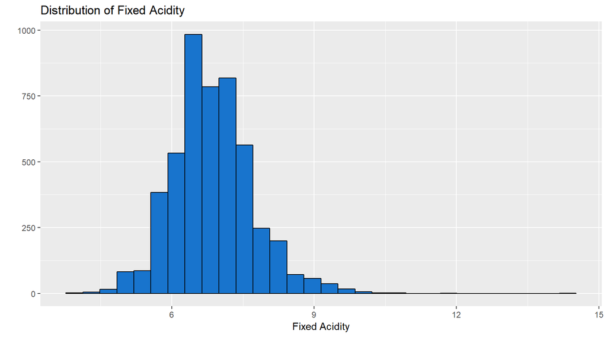

Volatile acidity: the amount of acetic acid in wine, which at too high of levels can lead to an unpleasant, vinegar taste. Normal distribution can be seen.

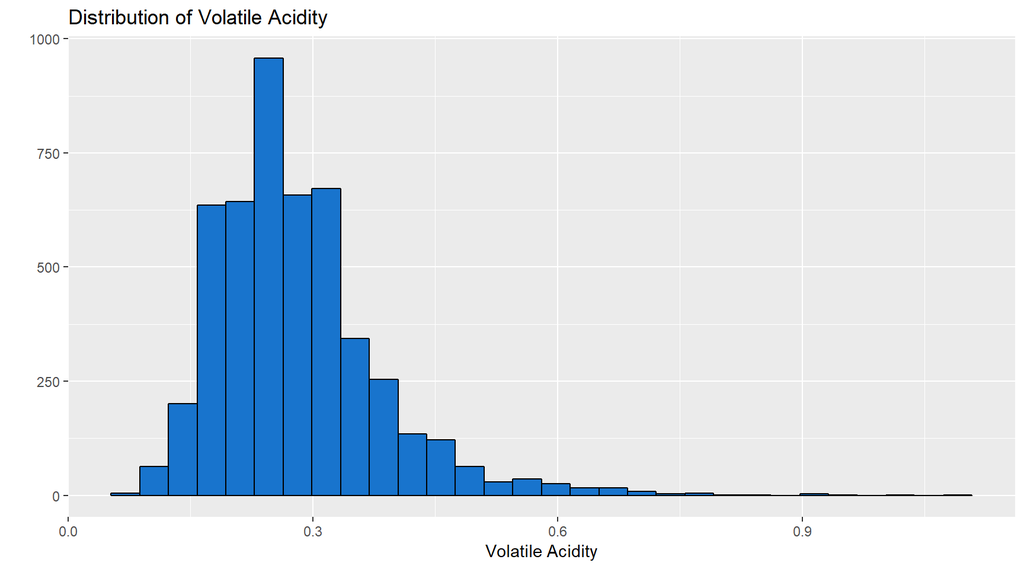

Citric acid: found in small quantities, citric acid can add ‘freshness’ and flavor to wines. Again, normal distribution is shown.

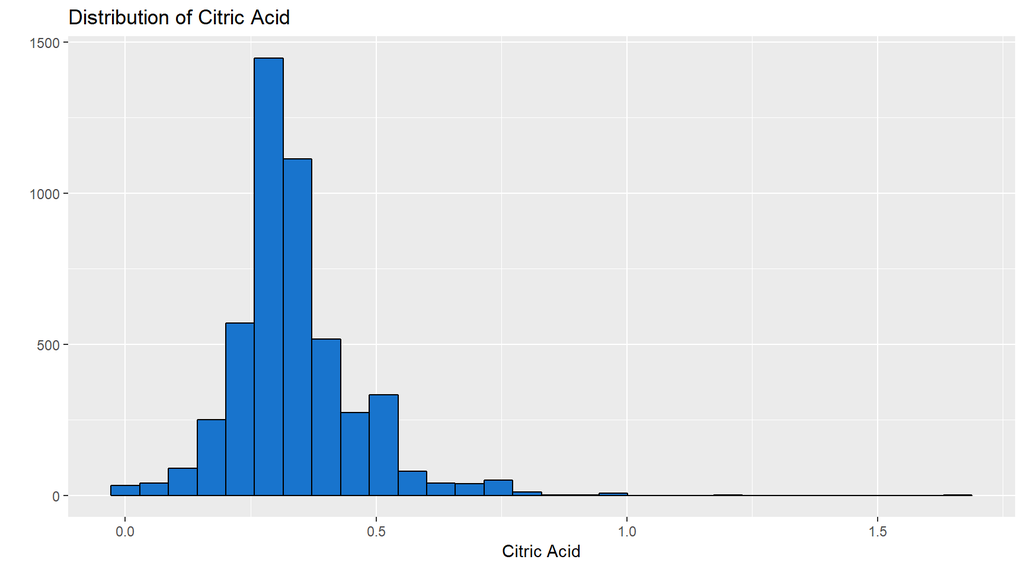

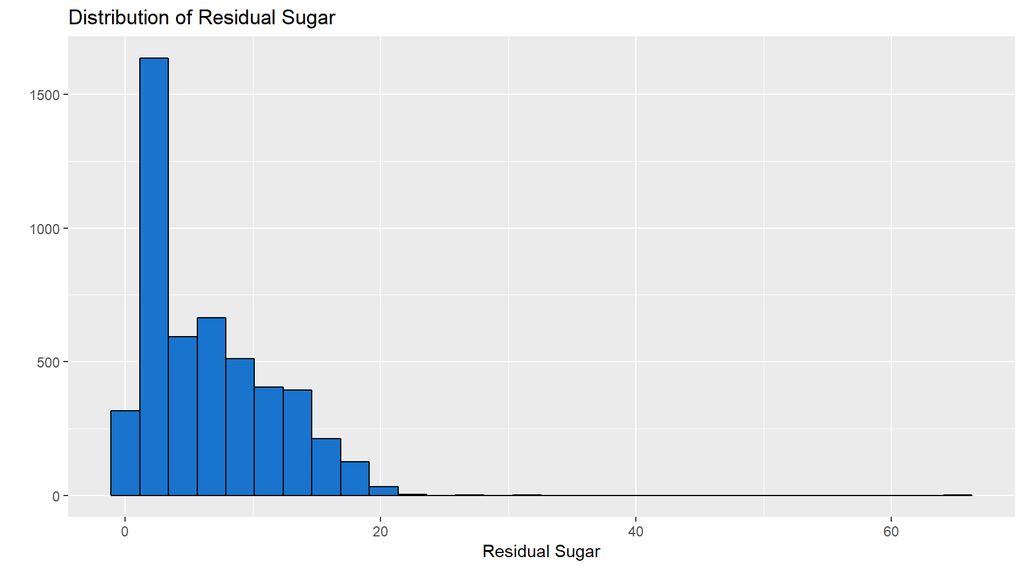

Surprisingly, a bimodal distribution ie, 2 peaks is displayed.

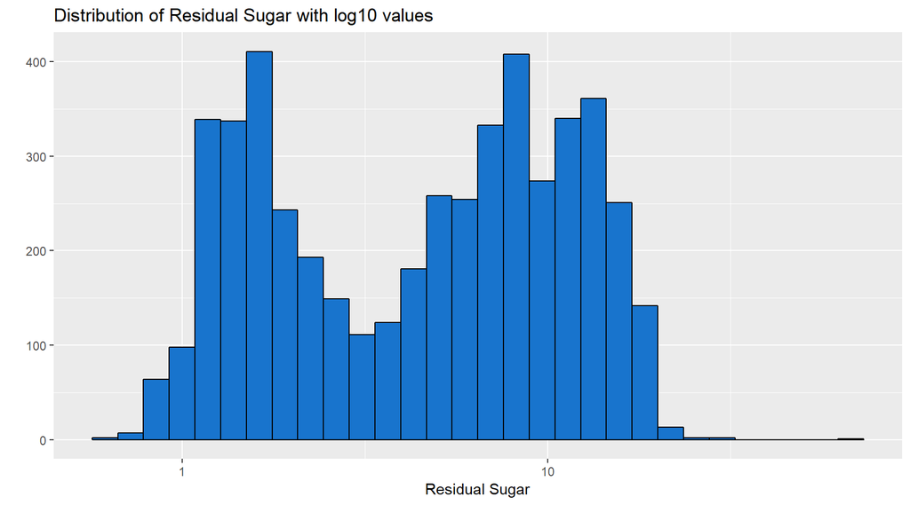

Chlorides: the amount of salt in the wine. 95 percentile is used for a clearer view with no outliers. Data is normally distributed.

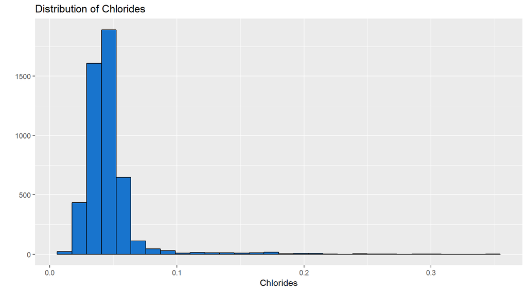

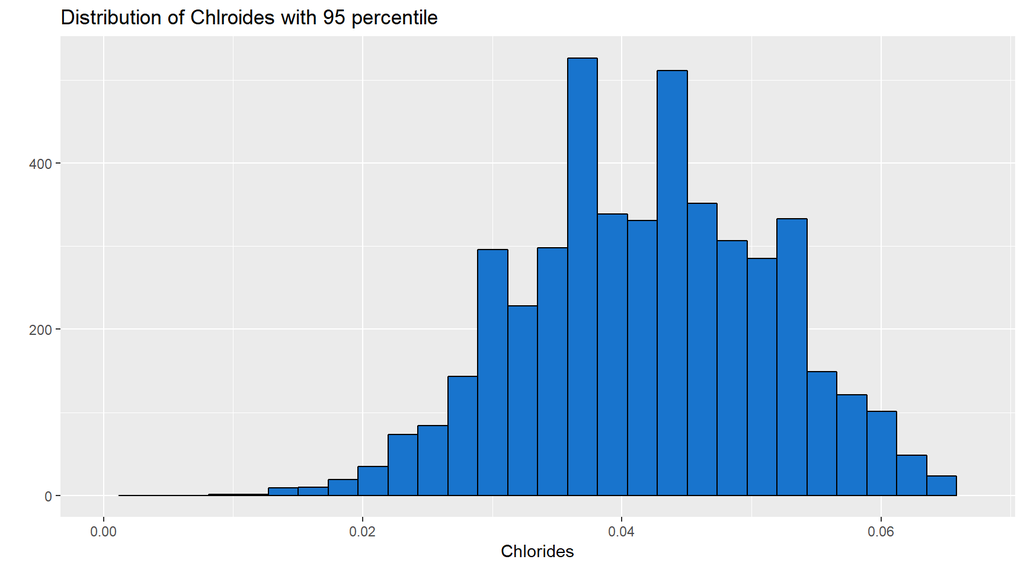

Free sulfur dioxide: the free form of SO2 exists in equilibrium between molecular SO2 (as a dissolved gas) and bisulfite ion; it prevents microbial growth and the oxidation of wine. Normally distributed data.

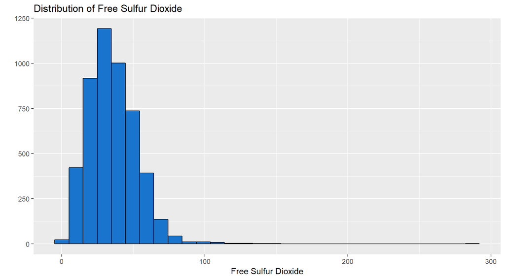

Total sulfur dioxide: amount of free and bound forms of S02; in low concentrations, SO2 is mostly undetectable in wine, but at free SO2 concentrations over 50 ppm, SO2 becomes evident in the nose and taste of wine. Normal distribution of data can be seen.

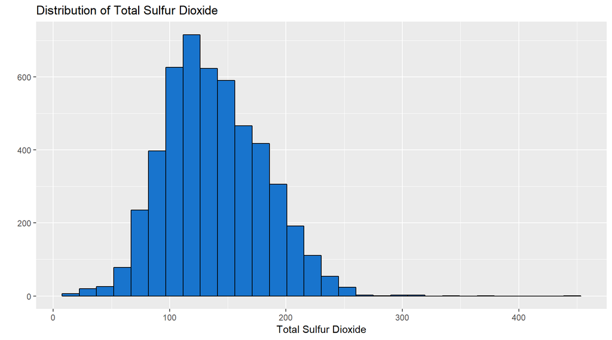

Density: the density of water is close to that of water depending on the percent alcohol and sugar content. Data is normally distrubuted.

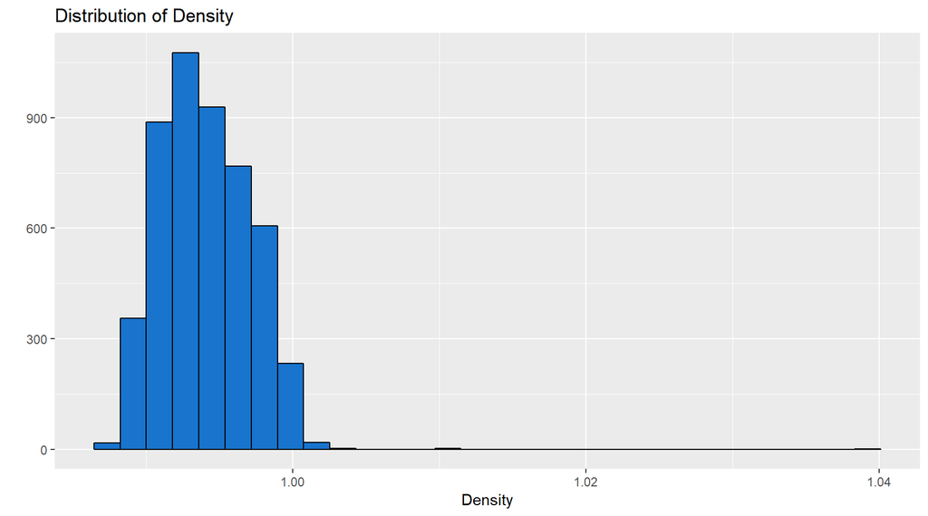

pH: describes how acidic or basic a wine is on a scale from 0 (very acidic) to 14 (very basic). Normal distribution of data.

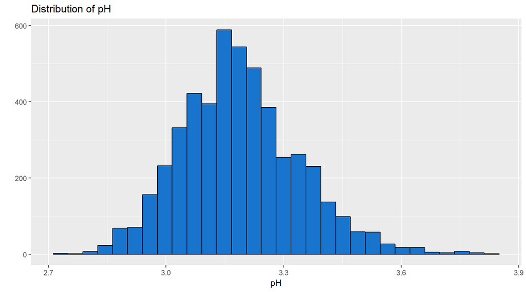

Sulphates: a wine additive which can contribute to sulfur dioxide gas (S02) levels, wich acts as an antimicrobial and antioxidant. Data appears to be normally distrubtued.

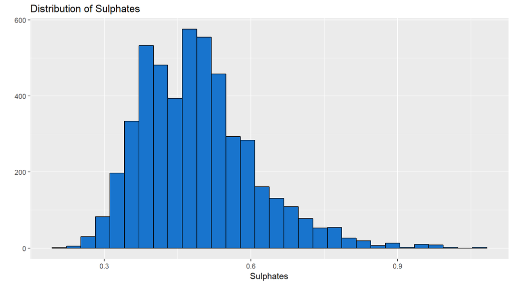

Alcohol: the percent alcohol content of the wine. Alcohol displays a very uneven distribution.

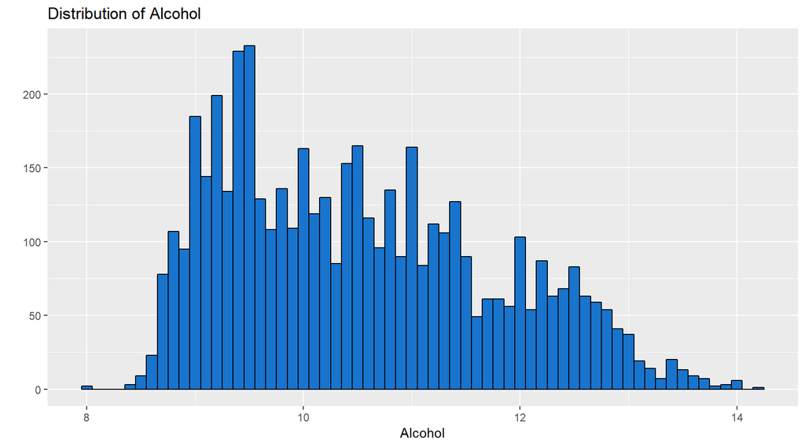

Quality appears to be normally distributed.

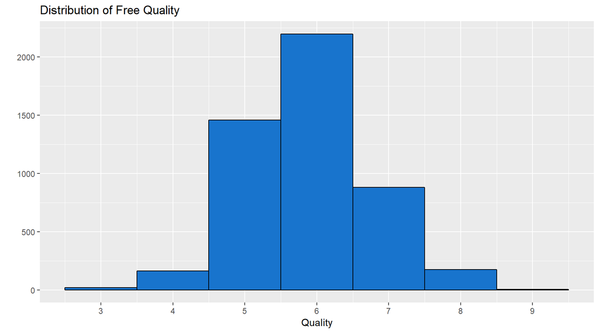

# Univariate Analysis

### What is the structure of your dataset?

The dataset contains 4898 observations with 12 variables, with 11 of them being input variables based on physiochemical tests which affect the quality of the wine which in turn, is the output variable.

### What is/are the main feature(s) of interest in your dataset?

We are mainly fixated on the quality of the wines and what affects it to what degree.

### Did you create any new variables from existing variables in the dataset?

A rating variable is created after this based on the quality variable. Average: 0-3, Good: 4-6, Excellent: 7-10

### Of the features you investigated, were there any unusual distributions?

While plotting the distributions of the data, the scale_x_log10 and 95th percentile were used for residual sugar and chlorides respectively.

# Bivariate Plots Section

First, we will have a look at the correlation matrix to determine strong and weak relationships between all the numeric variables.

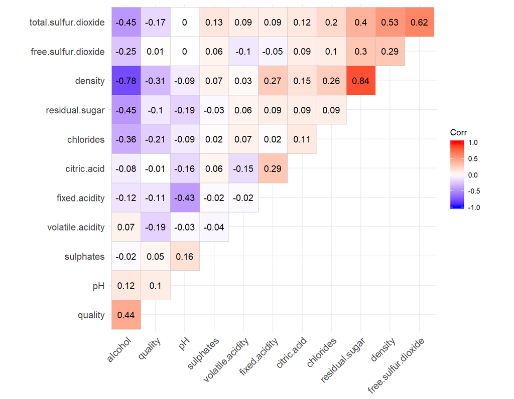

### Alcohol vs. Quality

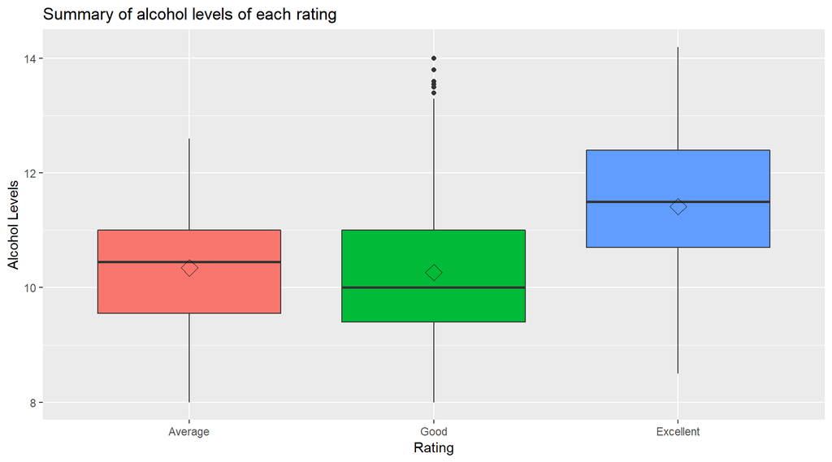

This plot shows the correlation between alcohol levels and quality.

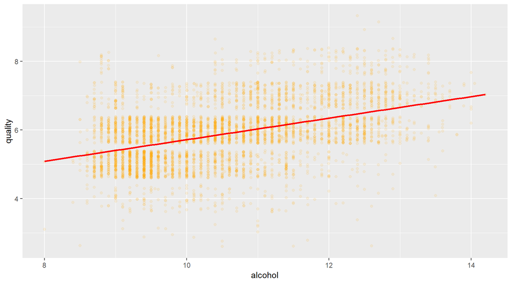

### Density vs. Quality

[figure not shown]

The correlation between density and quality is -0.31 which indicates a moderate negative relationship between the 2 variables. Higher density often leads to lower quality wines.

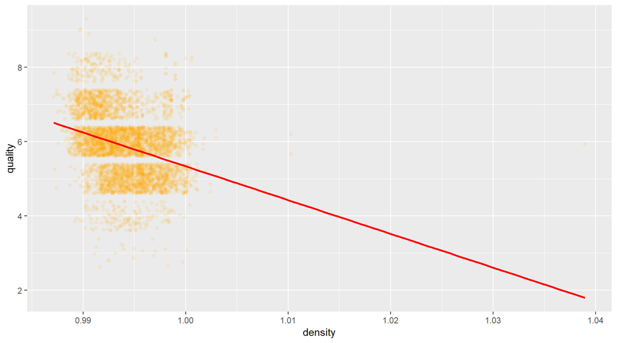

### Residual Sugar vs Density, Alcohol and Quality

This plot displays the relationship between residual sugar levels and density. A strong relationship is seen as residual sugar and density increase simultaneously.

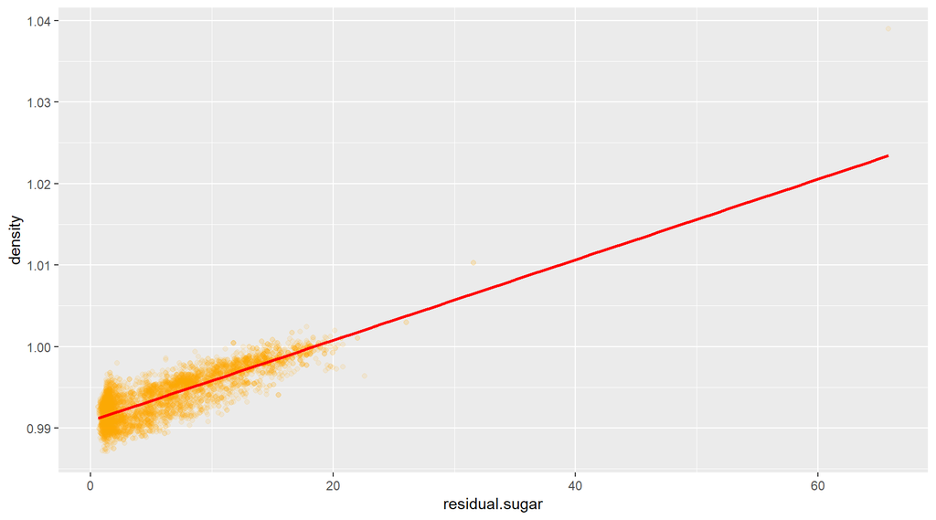

This plot displays the relationship between residual sugar levels and alcohol. It displays a pattern where as alcohol decreases, residual sugar increases.

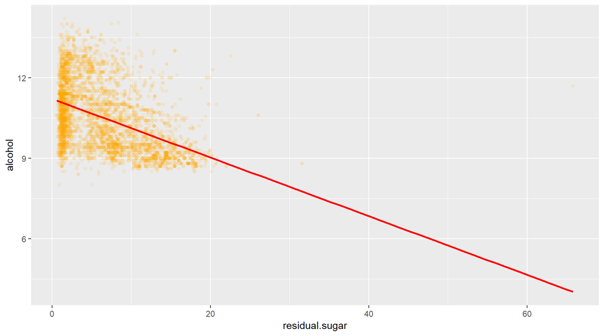

This plot shows the summary of residual sugar by ratings. A good wine has higher residual sugar than average and excellent quality wines.

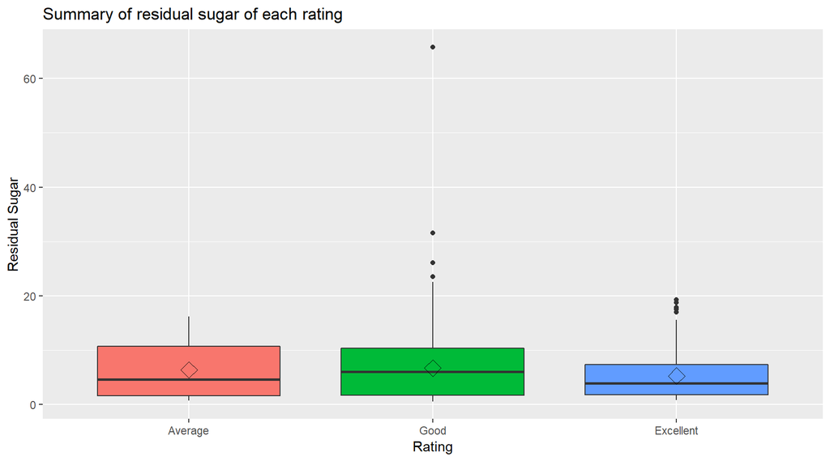

### Total Sulfur Dioxide vs. Density and Alcohol

This plot displays the relationship between total sulfur dioxide levels and density. Total sulfur dioxide and density increase at the same time.

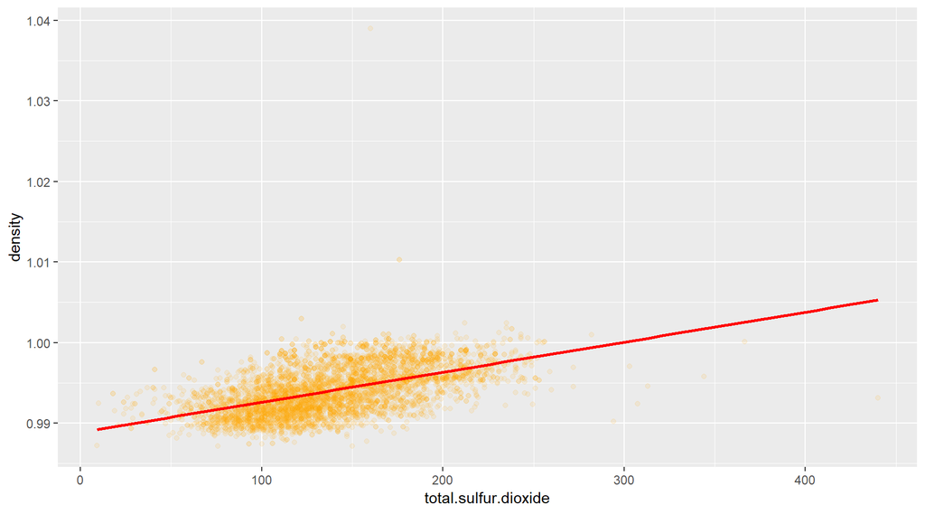

This plot displays the relationship between total sulfur dioxide levels and alcohol. Alcohol decreases as total sulfur dioxide increases.

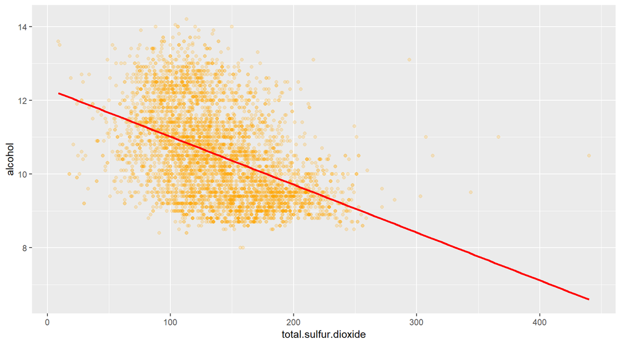

# Bivariate Analysis

### Did you observe any interesting relationships between the other features?

Both total sulfur dioxide and free sulfur dioxide had medium to strong relationsip with residual sugar and density. Alcohol seemed to have negative relationships with quite a lot of variables, them being density, residual sugar, chlorides, total and free sulfur dioxide.

### What was the strongest relationship you found?

Alcohol levels seemed to be strongly correlated to quality and density with residual sugar levels.

# Multivariate Plots Section

In this plot we can see that as the alcohol levels keep decreasing, residual sugar levels and density increases.

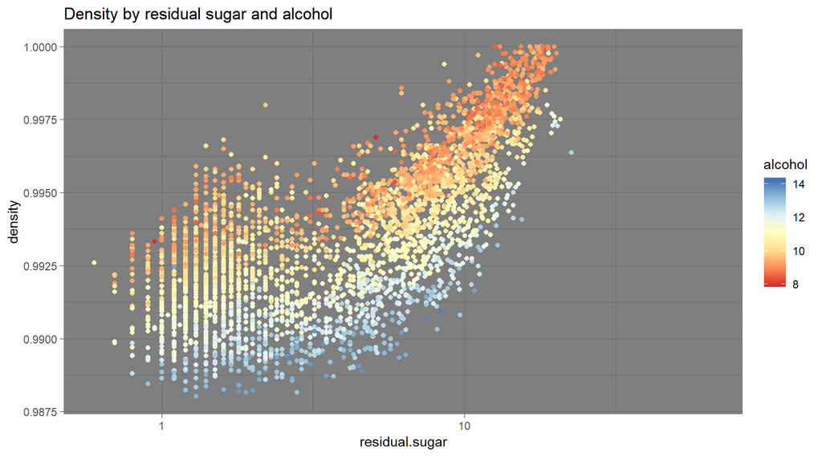

This plot shows the reationship of density with residual sugar and quality.

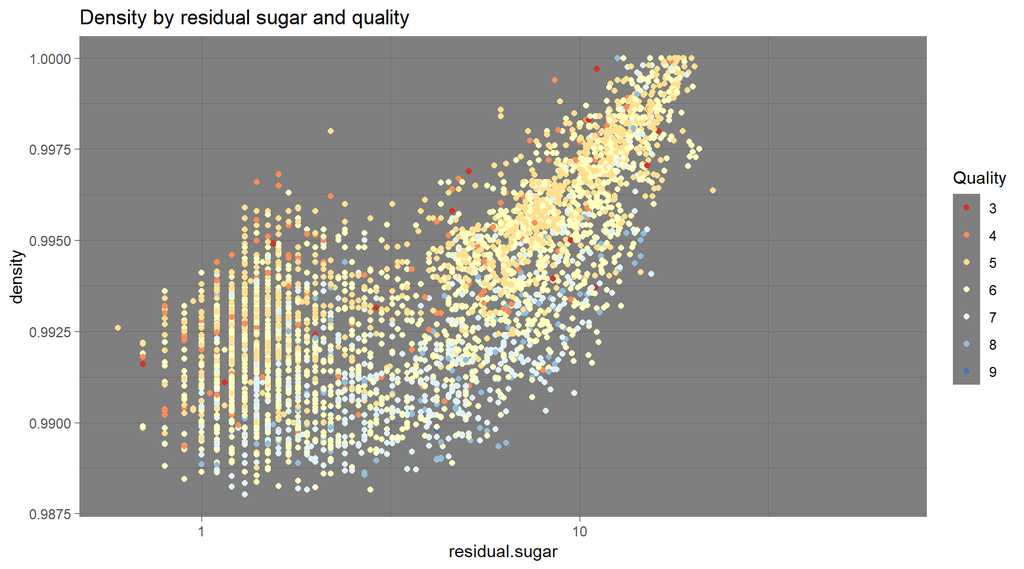

This plot shows density by quality and alcohol and we can see that alcohol and quality increases as density decreases.

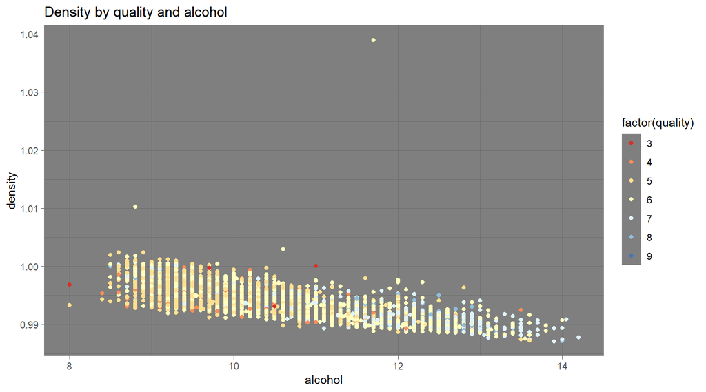

# Linear Model

```
##
## Call:
## lm(formula = quality ~ alcohol + chlorides + citric.acid + density +
##     fixed.acidity + free.sulfur.dioxide + pH + residual.sugar +
##     sulphates + total.sulfur.dioxide + volatile.acidity, data = pf)
##
## Residuals:
##     Min      1Q  Median      3Q     Max
## -3.8348 -0.4934 -0.0379  0.4637  3.1143
##
## Coefficients:
##                        Estimate Std. Error t value Pr(>|t|)
## (Intercept)           1.502e+02  1.880e+01   7.987 1.71e-15 ***
## alcohol               1.935e-01  2.422e-02   7.988 1.70e-15 ***
## chlorides            -2.473e-01  5.465e-01  -0.452  0.65097
## citric.acid           2.209e-02  9.577e-02   0.231  0.81759
## density              -1.503e+02  1.907e+01  -7.879 4.04e-15 ***
## fixed.acidity         6.552e-02  2.087e-02   3.139  0.00171 **
## free.sulfur.dioxide   3.733e-03  8.441e-04   4.422 9.99e-06 ***
## pH                    6.863e-01  1.054e-01   6.513 8.10e-11 ***
## residual.sugar        8.148e-02  7.527e-03  10.825  < 2e-16 ***
## sulphates             6.315e-01  1.004e-01   6.291 3.44e-10 ***
## total.sulfur.dioxide -2.857e-04  3.781e-04  -0.756  0.44979
## volatile.acidity     -1.863e+00  1.138e-01 -16.373  < 2e-16 ***
## ---
## Signif. codes:  0 '***' 0.001 '**' 0.01 '*' 0.05 '.' 0.1 ' ' 1
##
## Residual standard error: 0.7514 on 4886 degrees of freedom
## Multiple R-squared:  0.2819, Adjusted R-squared:  0.2803
## F-statistic: 174.3 on 11 and 4886 DF,  p-value: < 2.2e-16
```

# Multivariate Analysis

The strongest relationships are amongst quality, alcohol content and density of the wine.

### Were there any interesting or surprising interactions between features?

I didn’t have much prior knowledge about wines so I couldn’t make any educated guesses before analysing the data.

# Final Plots and Summary

### Plot One

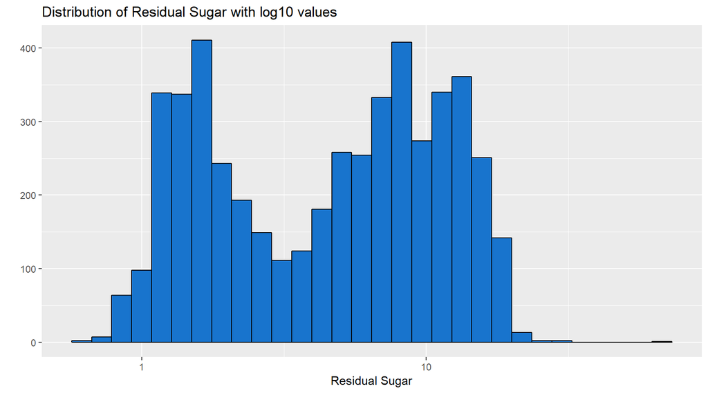

### Plot Two

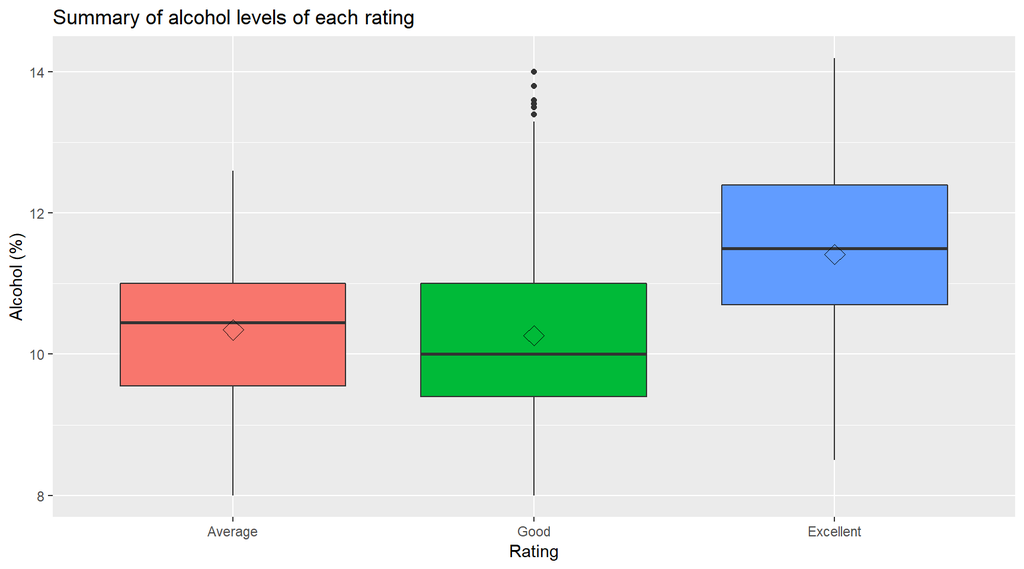

### Plot Three

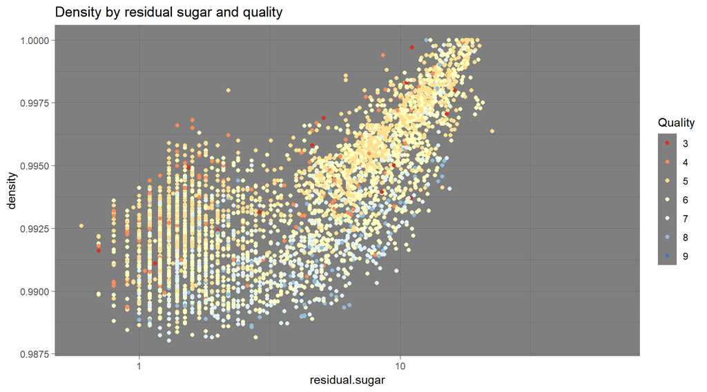

### Description Three

This plot shows the relationship of quality with residual sugar and density. It can be noticed that for a particular residual sugar value, density decreases and quality increases simultaneously and for a particular density value, reisudal sugar and quality both increase.

# Reflection

This analysis of the Portuguese “Vinho Verde” white wines was done in 3 parts, Univariate, Bivariate and Multivariate analysis. The focus was primarily on finding out what affects quality and 2 physiochemical measuremenets stood out from the rest, density and alcohol. Higher alcohol content and lower density of wines were mainly characteristics of higher quality wines. A linear regression model was made, but it didn’t seem to predict the quality with much accuracy. A huge challenege was figuring out what kind of comparisons to make amongst which particular variables. In the future, I would like to develop a model which could predict the quality of a wine based on the physiochemical properties provided in this data set. Also, I would prefer to obtain data from multiple companies as it eliminates any form of bias.

# References

https://stackoverflow.com/questions/37825558/how-to-use-superscript-with-ggplot2 https://www.nceas.ucsb.edu/~frazier/RSpatialGuides/colorPaletteCheatsheet.pdf

R documentaion